# Risk Factor Analysis

## Outcome Variable

**Outcome Variable:** stunted

## Predictor Variables

**Intervention Variable:** earlybf

**Adjustment Set:**

- arm
- sex
- W_mage
- meducyrs
- feducyrs
- hhwealth_quart
- hfoodsec
- W_mhtcm
- W_mwtkg
- W_mbmi
- vagbrth
- W_gagebrth
- W_birthwt
- W_birthlen
- W_nrooms
- W_nchldlt5
- brthmon
- W_parity
- impfloor
- impsan
- safeh20
- delta_W_mage
- delta_meducyrs
- delta_feducyrs
- delta_hhwealth_quart
- delta_hfoodsec
- delta_W_mhtcm
- delta_W_mwtkg
- delta_W_mbmi
- delta_vagbrth
- delta_W_gagebrth
- delta_W_birthwt
- delta_W_birthlen
- delta_W_nrooms
- delta_W_nchldlt5
- delta_brthmon
- delta_W_parity
- delta_impfloor
- delta_impsan
- delta_safeh20

## Stratifying Variables

The analysis was stratified on these variable(s):

- agecat
- studyid
- country

## Data Summary

| agecat | studyid | country | earlybf | stunted | n_cell | n |
| --- | --- | --- | --- | --- | --- | --- |
| Birth | EE | PAKISTAN | 1 | 0 | 28 | 229 |
| Birth | EE | PAKISTAN | 1 | 1 | 16 | 229 |
| Birth | EE | PAKISTAN | 0 | 0 | 105 | 229 |
| Birth | EE | PAKISTAN | 0 | 1 | 80 | 229 |
| Birth | GMS-Nepal | NEPAL | 1 | 0 | 152 | 632 |
| Birth | GMS-Nepal | NEPAL | 1 | 1 | 28 | 632 |
| Birth | GMS-Nepal | NEPAL | 0 | 0 | 373 | 632 |
| Birth | GMS-Nepal | NEPAL | 0 | 1 | 79 | 632 |
| Birth | JiVitA-3 | BANGLADESH | 1 | 0 | 85 | 22370 |
| Birth | JiVitA-3 | BANGLADESH | 1 | 1 | 151 | 22370 |
| Birth | JiVitA-3 | BANGLADESH | 0 | 0 | 14924 | 22370 |
| Birth | JiVitA-3 | BANGLADESH | 0 | 1 | 7210 | 22370 |
| Birth | JiVitA-4 | BANGLADESH | 1 | 0 | 1344 | 2823 |
| Birth | JiVitA-4 | BANGLADESH | 1 | 1 | 568 | 2823 |
| Birth | JiVitA-4 | BANGLADESH | 0 | 0 | 622 | 2823 |
| Birth | JiVitA-4 | BANGLADESH | 0 | 1 | 289 | 2823 |
| Birth | MAL-ED | BANGLADESH | 1 | 0 | 126 | 230 |
| Birth | MAL-ED | BANGLADESH | 1 | 1 | 21 | 230 |
| Birth | MAL-ED | BANGLADESH | 0 | 0 | 60 | 230 |
| Birth | MAL-ED | BANGLADESH | 0 | 1 | 23 | 230 |
| Birth | MAL-ED | BRAZIL | 1 | 0 | 26 | 65 |
| Birth | MAL-ED | BRAZIL | 1 | 1 | 2 | 65 |
| Birth | MAL-ED | BRAZIL | 0 | 0 | 30 | 65 |
| Birth | MAL-ED | BRAZIL | 0 | 1 | 7 | 65 |
| Birth | MAL-ED | INDIA | 1 | 0 | 25 | 46 |
| Birth | MAL-ED | INDIA | 1 | 1 | 7 | 46 |
| Birth | MAL-ED | INDIA | 0 | 0 | 11 | 46 |
| Birth | MAL-ED | INDIA | 0 | 1 | 3 | 46 |
| Birth | MAL-ED | NEPAL | 1 | 0 | 13 | 27 |
| Birth | MAL-ED | NEPAL | 1 | 1 | 1 | 27 |

[output cut: 134 more lines]

The following strata were considered:

- agecat: 24 months, studyid: EE, country: PAKISTAN
- agecat: 24 months, studyid: GMS-Nepal, country: NEPAL
- agecat: 24 months, studyid: JiVitA-3, country: BANGLADESH
- agecat: 24 months, studyid: JiVitA-4, country: BANGLADESH
- agecat: 24 months, studyid: MAL-ED, country: BANGLADESH
- agecat: 24 months, studyid: MAL-ED, country: BRAZIL
- agecat: 24 months, studyid: MAL-ED, country: INDIA
- agecat: 24 months, studyid: MAL-ED, country: NEPAL
- agecat: 24 months, studyid: MAL-ED, country: PERU
- agecat: 24 months, studyid: MAL-ED, country: SOUTH AFRICA
- agecat: 24 months, studyid: MAL-ED, country: TANZANIA, UNITED REPUBLIC OF
- agecat: 24 months, studyid: NIH-Crypto, country: BANGLADESH
- agecat: 24 months, studyid: ZVITAMBO, country: ZIMBABWE
- agecat: 6 months, studyid: EE, country: PAKISTAN
- agecat: 6 months, studyid: GMS-Nepal, country: NEPAL
- agecat: 6 months, studyid: JiVitA-3, country: BANGLADESH
- agecat: 6 months, studyid: JiVitA-4, country: BANGLADESH
- agecat: 6 months, studyid: MAL-ED, country: BANGLADESH
- agecat: 6 months, studyid: MAL-ED, country: BRAZIL
- agecat: 6 months, studyid: MAL-ED, country: INDIA
- agecat: 6 months, studyid: MAL-ED, country: NEPAL
- agecat: 6 months, studyid: MAL-ED, country: PERU
- agecat: 6 months, studyid: MAL-ED, country: SOUTH AFRICA
- agecat: 6 months, studyid: MAL-ED, country: TANZANIA, UNITED REPUBLIC OF
- agecat: 6 months, studyid: NIH-Crypto, country: BANGLADESH
- agecat: 6 months, studyid: SAS-CompFeed, country: INDIA
- agecat: 6 months, studyid: ZVITAMBO, country: ZIMBABWE
- agecat: Birth, studyid: EE, country: PAKISTAN
- agecat: Birth, studyid: GMS-Nepal, country: NEPAL
- agecat: Birth, studyid: JiVitA-3, country: BANGLADESH
- agecat: Birth, studyid: JiVitA-4, country: BANGLADESH
- agecat: Birth, studyid: MAL-ED, country: BANGLADESH
- agecat: Birth, studyid: MAL-ED, country: BRAZIL
- agecat: Birth, studyid: MAL-ED, country: INDIA
- agecat: Birth, studyid: MAL-ED, country: NEPAL
- agecat: Birth, studyid: MAL-ED, country: PERU
- agecat: Birth, studyid: MAL-ED, country: SOUTH AFRICA
- agecat: Birth, studyid: MAL-ED, country: TANZANIA, UNITED REPUBLIC OF
- agecat: Birth, studyid: NIH-Crypto, country: BANGLADESH
- agecat: Birth, studyid: SAS-CompFeed, country: INDIA
- agecat: Birth, studyid: ZVITAMBO, country: ZIMBABWE

### Dropped Strata

Some strata were dropped due to rare outcomes:

- agecat: Birth, studyid: MAL-ED, country: BRAZIL
- agecat: Birth, studyid: MAL-ED, country: INDIA
- agecat: Birth, studyid: MAL-ED, country: NEPAL
- agecat: Birth, studyid: MAL-ED, country: SOUTH AFRICA
- agecat: Birth, studyid: MAL-ED, country: TANZANIA, UNITED REPUBLIC OF
- agecat: 6 months, studyid: MAL-ED, country: BRAZIL
- agecat: 6 months, studyid: MAL-ED, country: NEPAL
- agecat: 24 months, studyid: JiVitA-3, country: BANGLADESH
- agecat: 24 months, studyid: MAL-ED, country: BRAZIL

## Methods Detail

We’re interested in the causal parameters $E[Y_a]$ for all values of $a \in \mathcal{A}$. These parameters represent the mean outcome if, possibly contrary to fact, we intervened to set all units to have $A=a$. Under the randomization and positivity assumptions, these are identified by the statistical parameters $\psi_a=E_W[E_{Y|A,W}(Y|A=a,W)]$. In addition, we’re interested in the mean of $Y$, $E[Y]$ under no intervention (the observed mean). We will estimate these parameters by using SuperLearner to fit the relevant likelihood factors – $E_{Y|A,W}(Y|A=a,W)$ and $p(A=a|W)$, and then updating our likelihood fit using a joint TMLE.

For unadjusted analyses ($W=\{\}$), initial likelihoods were estimated using Lrnr_glm to estimate the simple $E(Y|A)$ and Lrnr_mean to estimate $p(A)$. For adjusted analyses, a small library containing Lrnr_glmnet, Lrnr_xgboost, and Lrnr_mean was used.

Having estimated these parameters, we will then use the delta method to estimate relative risks and attributable risks relative to a prespecified baseline level of $A$.

# Results Detail

## Results Plots

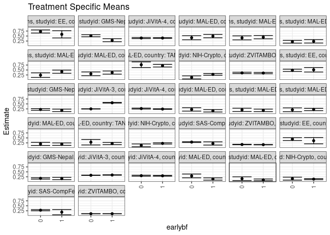

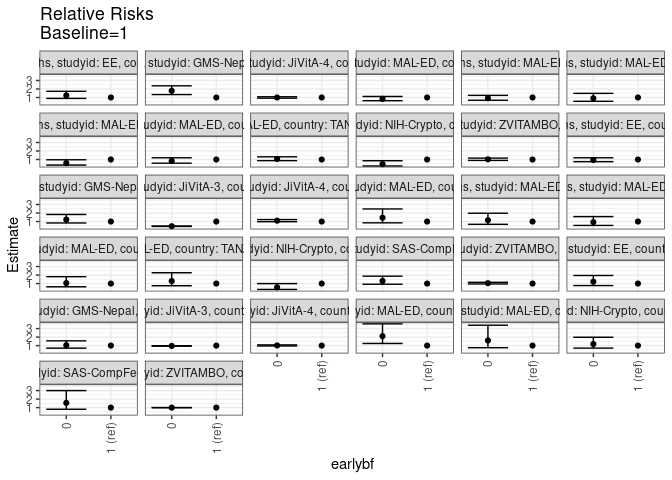

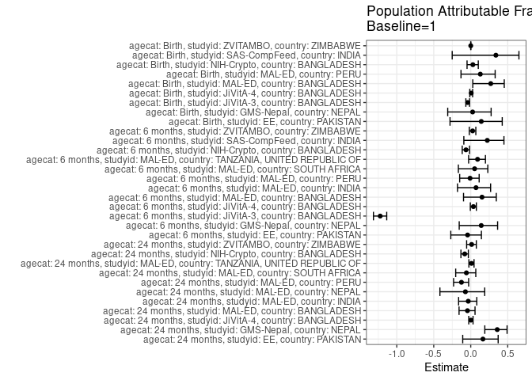

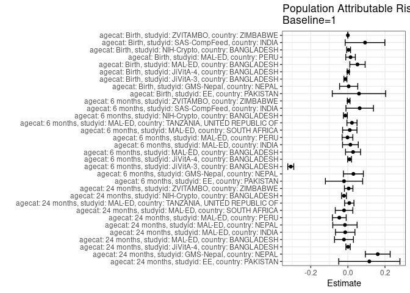

## Results Table

### Parameter: TSM

| agecat | studyid | country | intervention_level | baseline_level | estimate | ci_lower | ci_upper |
| --- | --- | --- | --- | --- | --- | --- | --- |
| Birth | EE | PAKISTAN | 1 | NA | 0.3593795 | 0.2024149 | 0.5163442 |
| Birth | EE | PAKISTAN | 0 | NA | 0.4382990 | 0.3663909 | 0.5102071 |
| Birth | GMS-Nepal | NEPAL | 1 | NA | 0.1649818 | 0.1082897 | 0.2216739 |
| Birth | GMS-Nepal | NEPAL | 0 | NA | 0.1724148 | 0.1374897 | 0.2073400 |
| Birth | JiVitA-3 | BANGLADESH | 1 | NA | 0.3425405 | 0.3316112 | 0.3534698 |
| Birth | JiVitA-3 | BANGLADESH | 0 | NA | 0.3289700 | 0.3215909 | 0.3363490 |
| Birth | JiVitA-4 | BANGLADESH | 1 | NA | 0.3015748 | 0.2814443 | 0.3217054 |
| Birth | JiVitA-4 | BANGLADESH | 0 | NA | 0.3076115 | 0.2829182 | 0.3323047 |
| Birth | MAL-ED | BANGLADESH | 1 | NA | 0.1394835 | 0.0824410 | 0.1965260 |
| Birth | MAL-ED | BANGLADESH | 0 | NA | 0.2941878 | 0.1981025 | 0.3902731 |
| Birth | MAL-ED | PERU | 1 | NA | 0.0971429 | 0.0531707 | 0.1411150 |
| Birth | MAL-ED | PERU | 0 | NA | 0.1551724 | 0.0617912 | 0.2485536 |
| Birth | NIH-Crypto | BANGLADESH | 1 | NA | 0.1339593 | 0.1074083 | 0.1605102 |
| Birth | NIH-Crypto | BANGLADESH | 0 | NA | 0.1584228 | 0.0832621 | 0.2335835 |
| Birth | SAS-CompFeed | INDIA | 1 | NA | 0.1793114 | 0.0480923 | 0.3105306 |
| Birth | SAS-CompFeed | INDIA | 0 | NA | 0.2789015 | 0.2498198 | 0.3079832 |
| Birth | ZVITAMBO | ZIMBABWE | 1 | NA | 0.1027677 | 0.0974134 | 0.1081219 |
| Birth | ZVITAMBO | ZIMBABWE | 0 | NA | 0.1028077 | 0.0974501 | 0.1081653 |
| 6 months | EE | PAKISTAN | 1 | NA | 0.5096564 | 0.3975035 | 0.6218092 |
| 6 months | EE | PAKISTAN | 0 | NA | 0.4839314 | 0.4272787 | 0.5405841 |
| 6 months | GMS-Nepal | NEPAL | 1 | NA | 0.1796086 | 0.1176762 | 0.2415411 |
| 6 months | GMS-Nepal | NEPAL | 0 | NA | 0.2214893 | 0.1784635 | 0.2645152 |
| 6 months | JiVitA-3 | BANGLADESH | 1 | NA | 0.5590313 | 0.5449593 | 0.5731033 |
| 6 months | JiVitA-3 | BANGLADESH | 0 | NA | 0.2507344 | 0.2424145 | 0.2590542 |
| 6 months | JiVitA-4 | BANGLADESH | 1 | NA | 0.2436006 | 0.2265376 | 0.2606637 |
| 6 months | JiVitA-4 | BANGLADESH | 0 | NA | 0.2679810 | 0.2435556 | 0.2924065 |
| 6 months | MAL-ED | BANGLADESH | 1 | NA | 0.1553695 | 0.0964236 | 0.2143155 |
| 6 months | MAL-ED | BANGLADESH | 0 | NA | 0.2254441 | 0.1406569 | 0.3102312 |
| 6 months | MAL-ED | INDIA | 1 | NA | 0.1770329 | 0.1138179 | 0.2402479 |
| 6 months | MAL-ED | INDIA | 0 | NA | 0.2041099 | 0.1221008 | 0.2861190 |
| 6 months | MAL-ED | PERU | 1 | NA | 0.2218027 | 0.1644075 | 0.2791979 |
| 6 months | MAL-ED | PERU | 0 | NA | 0.2055400 | 0.1094544 | 0.3016256 |
| 6 months | MAL-ED | SOUTH AFRICA | 1 | NA | 0.1857164 | 0.1236480 | 0.2477848 |
| 6 months | MAL-ED | SOUTH AFRICA | 0 | NA | 0.1968052 | 0.1152025 | 0.2784079 |
| 6 months | MAL-ED | TANZANIA, UNITED REPUBLIC OF | 1 | NA | 0.2168114 | 0.1600212 | 0.2736015 |
| 6 months | MAL-ED | TANZANIA, UNITED REPUBLIC OF | 0 | NA | 0.2823307 | 0.1436402 | 0.4210211 |
| 6 months | NIH-Crypto | BANGLADESH | 1 | NA | 0.2233373 | 0.1905225 | 0.2561520 |
| 6 months | NIH-Crypto | BANGLADESH | 0 | NA | 0.1246847 | 0.0547411 | 0.1946282 |
| 6 months | SAS-CompFeed | INDIA | 1 | NA | 0.2207278 | 0.1384822 | 0.3029734 |
| 6 months | SAS-CompFeed | INDIA | 0 | NA | 0.2893826 | 0.2718186 | 0.3069466 |
| 6 months | ZVITAMBO | ZIMBABWE | 1 | NA | 0.1599825 | 0.1491750 | 0.1707900 |
| 6 months | ZVITAMBO | ZIMBABWE | 0 | NA | 0.1675114 | 0.1556091 | 0.1794137 |
| 24 months | EE | PAKISTAN | 1 | NA | 0.5854859 | 0.4031123 | 0.7678596 |
| 24 months | EE | PAKISTAN | 0 | NA | 0.7270484 | 0.6505955 | 0.8035013 |
| 24 months | GMS-Nepal | NEPAL | 1 | NA | 0.2884386 | 0.2116340 | 0.3652431 |
| 24 months | GMS-Nepal | NEPAL | 0 | NA | 0.5145057 | 0.4594820 | 0.5695295 |
| 24 months | JiVitA-4 | BANGLADESH | 1 | NA | 0.3997675 | 0.3788245 | 0.4207105 |
| 24 months | JiVitA-4 | BANGLADESH | 0 | NA | 0.3998609 | 0.3730434 | 0.4266783 |
| 24 months | MAL-ED | BANGLADESH | 1 | NA | 0.4949334 | 0.4109284 | 0.5789384 |
| 24 months | MAL-ED | BANGLADESH | 0 | NA | 0.4135089 | 0.3103002 | 0.5167175 |
| 24 months | MAL-ED | INDIA | 1 | NA | 0.4417312 | 0.3580160 | 0.5254463 |
| 24 months | MAL-ED | INDIA | 0 | NA | 0.4067440 | 0.3070718 | 0.5064162 |
| 24 months | MAL-ED | NEPAL | 1 | NA | 0.2350669 | 0.1483180 | 0.3218158 |
| 24 months | MAL-ED | NEPAL | 0 | NA | 0.2130182 | 0.1421026 | 0.2839338 |
| 24 months | MAL-ED | PERU | 1 | NA | 0.4143319 | 0.3350198 | 0.4936441 |
| 24 months | MAL-ED | PERU | 0 | NA | 0.2400665 | 0.1243698 | 0.3557633 |
| 24 months | MAL-ED | SOUTH AFRICA | 1 | NA | 0.3694392 | 0.2906317 | 0.4482468 |
| 24 months | MAL-ED | SOUTH AFRICA | 0 | NA | 0.3065845 | 0.2116993 | 0.4014697 |
| 24 months | MAL-ED | TANZANIA, UNITED REPUBLIC OF | 1 | NA | 0.7166667 | 0.6506830 | 0.7826503 |
| 24 months | MAL-ED | TANZANIA, UNITED REPUBLIC OF | 0 | NA | 0.7647059 | 0.6217907 | 0.9076211 |
| 24 months | NIH-Crypto | BANGLADESH | 1 | NA | 0.2776524 | 0.2359085 | 0.3193963 |
| 24 months | NIH-Crypto | BANGLADESH | 0 | NA | 0.1267606 | 0.0492965 | 0.2042247 |
| 24 months | ZVITAMBO | ZIMBABWE | 1 | NA | 0.3456325 | 0.3119678 | 0.3792971 |
| 24 months | ZVITAMBO | ZIMBABWE | 0 | NA | 0.3529628 | 0.3181852 | 0.3877404 |

### Parameter: E(Y)

| agecat | studyid | country | intervention_level | baseline_level | estimate | ci_lower | ci_upper |
| --- | --- | --- | --- | --- | --- | --- | --- |
| Birth | EE | PAKISTAN | NA | NA | 0.4192140 | 0.3551658 | 0.4832621 |
| Birth | GMS-Nepal | NEPAL | NA | NA | 0.1693038 | 0.1400429 | 0.1985647 |
| Birth | JiVitA-3 | BANGLADESH | NA | NA | 0.3290568 | 0.3216837 | 0.3364298 |
| Birth | JiVitA-4 | BANGLADESH | NA | NA | 0.3035778 | 0.2836422 | 0.3235133 |
| Birth | MAL-ED | BANGLADESH | NA | NA | 0.1913043 | 0.1403613 | 0.2422474 |
| Birth | MAL-ED | PERU | NA | NA | 0.1115880 | 0.0710726 | 0.1521034 |
| Birth | NIH-Crypto | BANGLADESH | NA | NA | 0.1379781 | 0.1129774 | 0.1629789 |
| Birth | SAS-CompFeed | INDIA | NA | NA | 0.2717481 | 0.2380003 | 0.3054960 |
| Birth | ZVITAMBO | ZIMBABWE | NA | NA | 0.1028007 | 0.0974452 | 0.1081563 |
| 6 months | EE | PAKISTAN | NA | NA | 0.4889503 | 0.4373849 | 0.5405157 |
| 6 months | GMS-Nepal | NEPAL | NA | NA | 0.2093933 | 0.1740812 | 0.2447055 |
| 6 months | JiVitA-3 | BANGLADESH | NA | NA | 0.2513830 | 0.2432594 | 0.2595066 |
| 6 months | JiVitA-4 | BANGLADESH | NA | NA | 0.2527427 | 0.2386864 | 0.2667990 |
| 6 months | MAL-ED | BANGLADESH | NA | NA | 0.1833333 | 0.1342773 | 0.2323893 |
| 6 months | MAL-ED | INDIA | NA | NA | 0.1906780 | 0.1404524 | 0.2409036 |
| 6 months | MAL-ED | PERU | NA | NA | 0.2197802 | 0.1705687 | 0.2689917 |
| 6 months | MAL-ED | SOUTH AFRICA | NA | NA | 0.1960000 | 0.1466935 | 0.2453065 |
| 6 months | MAL-ED | TANZANIA, UNITED REPUBLIC OF | NA | NA | 0.2388664 | 0.1855834 | 0.2921494 |
| 6 months | NIH-Crypto | BANGLADESH | NA | NA | 0.2097902 | 0.1799252 | 0.2396552 |
| 6 months | SAS-CompFeed | INDIA | NA | NA | 0.2844311 | 0.2666491 | 0.3022132 |
| 6 months | ZVITAMBO | ZIMBABWE | NA | NA | 0.1641985 | 0.1559224 | 0.1724746 |
| 24 months | EE | PAKISTAN | NA | NA | 0.7012195 | 0.6309515 | 0.7714875 |
| 24 months | GMS-Nepal | NEPAL | NA | NA | 0.4494382 | 0.4031687 | 0.4957077 |
| 24 months | JiVitA-4 | BANGLADESH | NA | NA | 0.4008838 | 0.3839145 | 0.4178532 |
| 24 months | MAL-ED | BANGLADESH | NA | NA | 0.4739336 | 0.4064004 | 0.5414669 |
| 24 months | MAL-ED | INDIA | NA | NA | 0.4273128 | 0.3628178 | 0.4918077 |
| 24 months | MAL-ED | NEPAL | NA | NA | 0.2192982 | 0.1654718 | 0.2731246 |
| 24 months | MAL-ED | PERU | NA | NA | 0.3681592 | 0.3013164 | 0.4350020 |
| 24 months | MAL-ED | SOUTH AFRICA | NA | NA | 0.3489362 | 0.2878666 | 0.4100058 |
| 24 months | MAL-ED | TANZANIA, UNITED REPUBLIC OF | NA | NA | 0.7242991 | 0.6642873 | 0.7843108 |
| 24 months | NIH-Crypto | BANGLADESH | NA | NA | 0.2568093 | 0.2190047 | 0.2946140 |
| 24 months | ZVITAMBO | ZIMBABWE | NA | NA | 0.3499289 | 0.3249898 | 0.3748679 |

### Parameter: RR

| agecat | studyid | country | intervention_level | baseline_level | estimate | ci_lower | ci_upper |
| --- | --- | --- | --- | --- | --- | --- | --- |
| Birth | EE | PAKISTAN | 1 | 1 | 1.0000000 | 1.0000000 | 1.0000000 |
| Birth | EE | PAKISTAN | 0 | 1 | 1.2195992 | 0.7639570 | 1.9469971 |
| Birth | GMS-Nepal | NEPAL | 1 | 1 | 1.0000000 | 1.0000000 | 1.0000000 |
| Birth | GMS-Nepal | NEPAL | 0 | 1 | 1.0450537 | 0.7014924 | 1.5568767 |
| Birth | JiVitA-3 | BANGLADESH | 1 | 1 | 1.0000000 | 1.0000000 | 1.0000000 |
| Birth | JiVitA-3 | BANGLADESH | 0 | 1 | 0.9603828 | 0.9371584 | 0.9841827 |
| Birth | JiVitA-4 | BANGLADESH | 1 | 1 | 1.0000000 | 1.0000000 | 1.0000000 |
| Birth | JiVitA-4 | BANGLADESH | 0 | 1 | 1.0200171 | 0.9602226 | 1.0835350 |
| Birth | MAL-ED | BANGLADESH | 1 | 1 | 1.0000000 | 1.0000000 | 1.0000000 |
| Birth | MAL-ED | BANGLADESH | 0 | 1 | 2.1091224 | 1.2499409 | 3.5588860 |
| Birth | MAL-ED | PERU | 1 | 1 | 1.0000000 | 1.0000000 | 1.0000000 |
| Birth | MAL-ED | PERU | 0 | 1 | 1.5973631 | 0.7522615 | 3.3918642 |
| Birth | NIH-Crypto | BANGLADESH | 1 | 1 | 1.0000000 | 1.0000000 | 1.0000000 |
| Birth | NIH-Crypto | BANGLADESH | 0 | 1 | 1.1826191 | 0.7072219 | 1.9775800 |
| Birth | SAS-CompFeed | INDIA | 1 | 1 | 1.0000000 | 1.0000000 | 1.0000000 |
| Birth | SAS-CompFeed | INDIA | 0 | 1 | 1.5554027 | 0.8060710 | 3.0013206 |
| Birth | ZVITAMBO | ZIMBABWE | 1 | 1 | 1.0000000 | 1.0000000 | 1.0000000 |
| Birth | ZVITAMBO | ZIMBABWE | 0 | 1 | 1.0003897 | 0.9984724 | 1.0023106 |
| 6 months | EE | PAKISTAN | 1 | 1 | 1.0000000 | 1.0000000 | 1.0000000 |
| 6 months | EE | PAKISTAN | 0 | 1 | 0.9495249 | 0.7462380 | 1.2081903 |
| 6 months | GMS-Nepal | NEPAL | 1 | 1 | 1.0000000 | 1.0000000 | 1.0000000 |
| 6 months | GMS-Nepal | NEPAL | 0 | 1 | 1.2331775 | 0.8303892 | 1.8313424 |
| 6 months | JiVitA-3 | BANGLADESH | 1 | 1 | 1.0000000 | 1.0000000 | 1.0000000 |
| 6 months | JiVitA-3 | BANGLADESH | 0 | 1 | 0.4485158 | 0.4301190 | 0.4676994 |
| 6 months | JiVitA-4 | BANGLADESH | 1 | 1 | 1.0000000 | 1.0000000 | 1.0000000 |
| 6 months | JiVitA-4 | BANGLADESH | 0 | 1 | 1.1000835 | 0.9824982 | 1.2317413 |
| 6 months | MAL-ED | BANGLADESH | 1 | 1 | 1.0000000 | 1.0000000 | 1.0000000 |
| 6 months | MAL-ED | BANGLADESH | 0 | 1 | 1.4510183 | 0.8494857 | 2.4785043 |
| 6 months | MAL-ED | INDIA | 1 | 1 | 1.0000000 | 1.0000000 | 1.0000000 |
| 6 months | MAL-ED | INDIA | 0 | 1 | 1.1529488 | 0.6722588 | 1.9773498 |
| 6 months | MAL-ED | PERU | 1 | 1 | 1.0000000 | 1.0000000 | 1.0000000 |
| 6 months | MAL-ED | PERU | 0 | 1 | 0.9266795 | 0.5434895 | 1.5800394 |
| 6 months | MAL-ED | SOUTH AFRICA | 1 | 1 | 1.0000000 | 1.0000000 | 1.0000000 |
| 6 months | MAL-ED | SOUTH AFRICA | 0 | 1 | 1.0597084 | 0.6211384 | 1.8079417 |
| 6 months | MAL-ED | TANZANIA, UNITED REPUBLIC OF | 1 | 1 | 1.0000000 | 1.0000000 | 1.0000000 |
| 6 months | MAL-ED | TANZANIA, UNITED REPUBLIC OF | 0 | 1 | 1.3021950 | 0.7460304 | 2.2729795 |
| 6 months | NIH-Crypto | BANGLADESH | 1 | 1 | 1.0000000 | 1.0000000 | 1.0000000 |
| 6 months | NIH-Crypto | BANGLADESH | 0 | 1 | 0.5582798 | 0.3125679 | 0.9971475 |
| 6 months | SAS-CompFeed | INDIA | 1 | 1 | 1.0000000 | 1.0000000 | 1.0000000 |
| 6 months | SAS-CompFeed | INDIA | 0 | 1 | 1.3110384 | 0.9205755 | 1.8671164 |
| 6 months | ZVITAMBO | ZIMBABWE | 1 | 1 | 1.0000000 | 1.0000000 | 1.0000000 |
| 6 months | ZVITAMBO | ZIMBABWE | 0 | 1 | 1.0470604 | 0.9529205 | 1.1505005 |
| 24 months | EE | PAKISTAN | 1 | 1 | 1.0000000 | 1.0000000 | 1.0000000 |
| 24 months | EE | PAKISTAN | 0 | 1 | 1.2417864 | 0.8922757 | 1.7282028 |
| 24 months | GMS-Nepal | NEPAL | 1 | 1 | 1.0000000 | 1.0000000 | 1.0000000 |
| 24 months | GMS-Nepal | NEPAL | 0 | 1 | 1.7837620 | 1.3422717 | 2.3704639 |
| 24 months | JiVitA-4 | BANGLADESH | 1 | 1 | 1.0000000 | 1.0000000 | 1.0000000 |
| 24 months | JiVitA-4 | BANGLADESH | 0 | 1 | 1.0002336 | 0.9222204 | 1.0848462 |
| 24 months | MAL-ED | BANGLADESH | 1 | 1 | 1.0000000 | 1.0000000 | 1.0000000 |
| 24 months | MAL-ED | BANGLADESH | 0 | 1 | 0.8354838 | 0.6237685 | 1.1190581 |
| 24 months | MAL-ED | INDIA | 1 | 1 | 1.0000000 | 1.0000000 | 1.0000000 |
| 24 months | MAL-ED | INDIA | 0 | 1 | 0.9207953 | 0.6794974 | 1.2477813 |
| 24 months | MAL-ED | NEPAL | 1 | 1 | 1.0000000 | 1.0000000 | 1.0000000 |
| 24 months | MAL-ED | NEPAL | 0 | 1 | 0.9062023 | 0.5534062 | 1.4839057 |
| 24 months | MAL-ED | PERU | 1 | 1 | 1.0000000 | 1.0000000 | 1.0000000 |
| 24 months | MAL-ED | PERU | 0 | 1 | 0.5794063 | 0.3465035 | 0.9688551 |
| 24 months | MAL-ED | SOUTH AFRICA | 1 | 1 | 1.0000000 | 1.0000000 | 1.0000000 |
| 24 months | MAL-ED | SOUTH AFRICA | 0 | 1 | 0.8298645 | 0.5716188 | 1.2047804 |
| 24 months | MAL-ED | TANZANIA, UNITED REPUBLIC OF | 1 | 1 | 1.0000000 | 1.0000000 | 1.0000000 |
| 24 months | MAL-ED | TANZANIA, UNITED REPUBLIC OF | 0 | 1 | 1.0670315 | 0.8663581 | 1.3141865 |
| 24 months | NIH-Crypto | BANGLADESH | 1 | 1 | 1.0000000 | 1.0000000 | 1.0000000 |
| 24 months | NIH-Crypto | BANGLADESH | 0 | 1 | 0.4565441 | 0.2433150 | 0.8566365 |
| 24 months | ZVITAMBO | ZIMBABWE | 1 | 1 | 1.0000000 | 1.0000000 | 1.0000000 |
| 24 months | ZVITAMBO | ZIMBABWE | 0 | 1 | 1.0212084 | 0.8933250 | 1.1673989 |

### Parameter: PAR

| agecat | studyid | country | intervention_level | baseline_level | estimate | ci_lower | ci_upper |
| --- | --- | --- | --- | --- | --- | --- | --- |
| Birth | EE | PAKISTAN | 1 | NA | 0.0598344 | -0.0840274 | 0.2036963 |
| Birth | GMS-Nepal | NEPAL | 1 | NA | 0.0043220 | -0.0446355 | 0.0532795 |
| Birth | JiVitA-3 | BANGLADESH | 1 | NA | -0.0134837 | -0.0216415 | -0.0053259 |
| Birth | JiVitA-4 | BANGLADESH | 1 | NA | 0.0020029 | -0.0039311 | 0.0079370 |
| Birth | MAL-ED | BANGLADESH | 1 | NA | 0.0518208 | 0.0105682 | 0.0930735 |
| Birth | MAL-ED | PERU | 1 | NA | 0.0144451 | -0.0114503 | 0.0403405 |
| Birth | NIH-Crypto | BANGLADESH | 1 | NA | 0.0040189 | -0.0064656 | 0.0145034 |
| Birth | SAS-CompFeed | INDIA | 1 | NA | 0.0924367 | -0.0144782 | 0.1993516 |
| Birth | ZVITAMBO | ZIMBABWE | 1 | NA | 0.0000331 | -0.0000666 | 0.0001327 |
| 6 months | EE | PAKISTAN | 1 | NA | -0.0207061 | -0.1211507 | 0.0797385 |
| 6 months | GMS-Nepal | NEPAL | 1 | NA | 0.0297847 | -0.0239297 | 0.0834991 |
| 6 months | JiVitA-3 | BANGLADESH | 1 | NA | -0.3076483 | -0.3236811 | -0.2916154 |
| 6 months | JiVitA-4 | BANGLADESH | 1 | NA | 0.0091421 | -0.0011633 | 0.0194474 |
| 6 months | MAL-ED | BANGLADESH | 1 | NA | 0.0279638 | -0.0125733 | 0.0685009 |
| 6 months | MAL-ED | INDIA | 1 | NA | 0.0136451 | -0.0287574 | 0.0560475 |
| 6 months | MAL-ED | PERU | 1 | NA | -0.0020225 | -0.0308918 | 0.0268468 |
| 6 months | MAL-ED | SOUTH AFRICA | 1 | NA | 0.0102836 | -0.0284035 | 0.0489708 |
| 6 months | MAL-ED | TANZANIA, UNITED REPUBLIC OF | 1 | NA | 0.0220550 | -0.0051780 | 0.0492881 |
| 6 months | NIH-Crypto | BANGLADESH | 1 | NA | -0.0135471 | -0.0239693 | -0.0031248 |
| 6 months | SAS-CompFeed | INDIA | 1 | NA | 0.0637033 | -0.0103821 | 0.1377887 |
| 6 months | ZVITAMBO | ZIMBABWE | 1 | NA | 0.0042160 | -0.0030503 | 0.0114823 |
| 24 months | EE | PAKISTAN | 1 | NA | 0.1157336 | -0.0490721 | 0.2805393 |
| 24 months | GMS-Nepal | NEPAL | 1 | NA | 0.1609996 | 0.0940333 | 0.2279660 |
| 24 months | JiVitA-4 | BANGLADESH | 1 | NA | 0.0011164 | -0.0105272 | 0.0127600 |
| 24 months | MAL-ED | BANGLADESH | 1 | NA | -0.0209997 | -0.0719749 | 0.0299754 |
| 24 months | MAL-ED | INDIA | 1 | NA | -0.0144184 | -0.0668002 | 0.0379635 |
| 24 months | MAL-ED | NEPAL | 1 | NA | -0.0157687 | -0.0813791 | 0.0498418 |
| 24 months | MAL-ED | PERU | 1 | NA | -0.0461727 | -0.0833688 | -0.0089767 |
| 24 months | MAL-ED | SOUTH AFRICA | 1 | NA | -0.0205031 | -0.0677869 | 0.0267808 |
| 24 months | MAL-ED | TANZANIA, UNITED REPUBLIC OF | 1 | NA | 0.0076324 | -0.0174880 | 0.0327528 |
| 24 months | NIH-Crypto | BANGLADESH | 1 | NA | -0.0208430 | -0.0338062 | -0.0078799 |
| 24 months | ZVITAMBO | ZIMBABWE | 1 | NA | 0.0042964 | -0.0185873 | 0.0271802 |

### Parameter: PAF

| agecat | studyid | country | intervention_level | baseline_level | estimate | ci_lower | ci_upper |
| --- | --- | --- | --- | --- | --- | --- | --- |
| Birth | EE | PAKISTAN | 1 | NA | 0.1427301 | -0.2800383 | 0.4258674 |
| Birth | GMS-Nepal | NEPAL | 1 | NA | 0.0255282 | -0.3110890 | 0.2757202 |
| Birth | JiVitA-3 | BANGLADESH | 1 | NA | -0.0409768 | -0.0660948 | -0.0164507 |
| Birth | JiVitA-4 | BANGLADESH | 1 | NA | 0.0065978 | -0.0130964 | 0.0259091 |
| Birth | MAL-ED | BANGLADESH | 1 | NA | 0.2708816 | 0.0278880 | 0.4531354 |
| Birth | MAL-ED | PERU | 1 | NA | 0.1294505 | -0.1316004 | 0.3302792 |
| Birth | NIH-Crypto | BANGLADESH | 1 | NA | 0.0291267 | -0.0497840 | 0.1021059 |
| Birth | SAS-CompFeed | INDIA | 1 | NA | 0.3401558 | -0.2505965 | 0.6518506 |
| Birth | ZVITAMBO | ZIMBABWE | 1 | NA | 0.0003216 | -0.0006476 | 0.0012899 |
| 6 months | EE | PAKISTAN | 1 | NA | -0.0423481 | -0.2695668 | 0.1442046 |
| 6 months | GMS-Nepal | NEPAL | 1 | NA | 0.1422428 | -0.1557499 | 0.3634026 |
| 6 months | JiVitA-3 | BANGLADESH | 1 | NA | -1.2238227 | -1.3153967 | -1.1358705 |
| 6 months | JiVitA-4 | BANGLADESH | 1 | NA | 0.0361715 | -0.0054376 | 0.0760585 |
| 6 months | MAL-ED | BANGLADESH | 1 | NA | 0.1525297 | -0.0973261 | 0.3454946 |
| 6 months | MAL-ED | INDIA | 1 | NA | 0.0715608 | -0.1788979 | 0.2688091 |
| 6 months | MAL-ED | PERU | 1 | NA | -0.0092023 | -0.1494754 | 0.1139529 |
| 6 months | MAL-ED | SOUTH AFRICA | 1 | NA | 0.0524675 | -0.1672023 | 0.2307950 |
| 6 months | MAL-ED | TANZANIA, UNITED REPUBLIC OF | 1 | NA | 0.0923321 | -0.0283931 | 0.1988851 |
| 6 months | NIH-Crypto | BANGLADESH | 1 | NA | -0.0645743 | -0.1151415 | -0.0163001 |
| 6 months | SAS-CompFeed | INDIA | 1 | NA | 0.2239675 | -0.0931500 | 0.4490908 |
| 6 months | ZVITAMBO | ZIMBABWE | 1 | NA | 0.0256760 | -0.0195668 | 0.0689113 |
| 24 months | EE | PAKISTAN | 1 | NA | 0.1650462 | -0.1082607 | 0.3709532 |
| 24 months | GMS-Nepal | NEPAL | 1 | NA | 0.3582242 | 0.1902038 | 0.4913830 |
| 24 months | JiVitA-4 | BANGLADESH | 1 | NA | 0.0027848 | -0.0266921 | 0.0314154 |
| 24 months | MAL-ED | BANGLADESH | 1 | NA | -0.0443095 | -0.1579102 | 0.0581461 |
| 24 months | MAL-ED | INDIA | 1 | NA | -0.0337420 | -0.1639208 | 0.0818769 |
| 24 months | MAL-ED | NEPAL | 1 | NA | -0.0719051 | -0.4166335 | 0.1889359 |
| 24 months | MAL-ED | PERU | 1 | NA | -0.1254151 | -0.2317282 | -0.0282781 |
| 24 months | MAL-ED | SOUTH AFRICA | 1 | NA | -0.0587588 | -0.2032682 | 0.0683954 |
| 24 months | MAL-ED | TANZANIA, UNITED REPUBLIC OF | 1 | NA | 0.0105376 | -0.0248074 | 0.0446637 |
| 24 months | NIH-Crypto | BANGLADESH | 1 | NA | -0.0811615 | -0.1324602 | -0.0321865 |
| 24 months | ZVITAMBO | ZIMBABWE | 1 | NA | 0.0122780 | -0.0553270 | 0.0755522 |